# Factsheet MapBiomas Fuego Argentina, septiembre 2026

#### Las tres regiones, sueltas

Los mismos tres paneles de arriba, cada uno en su archivo (`fig10`, `fig11`, `fig12`), por si conviene ubicarlos por separado en vez de en bloque.

**Código**

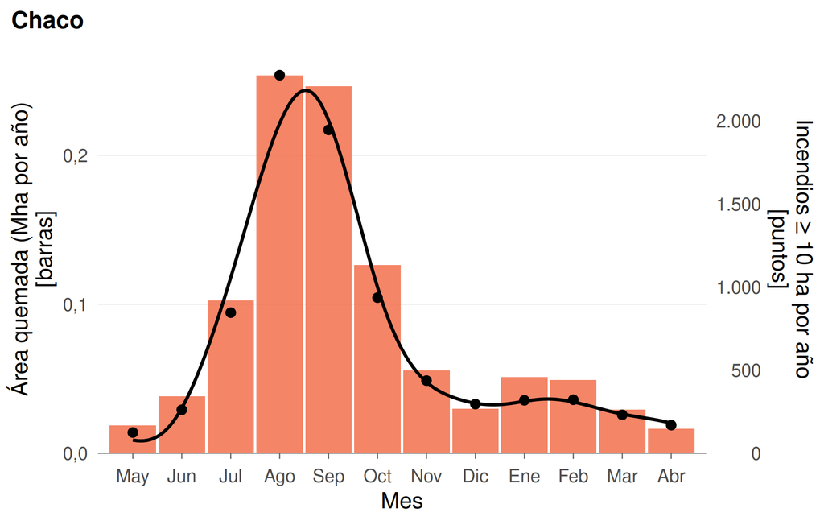

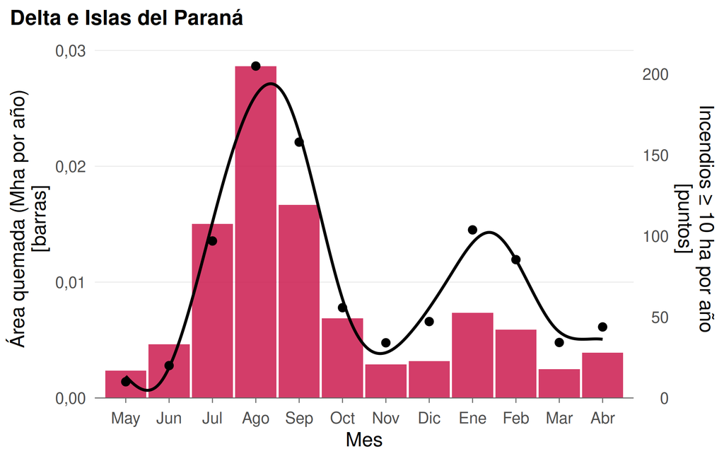

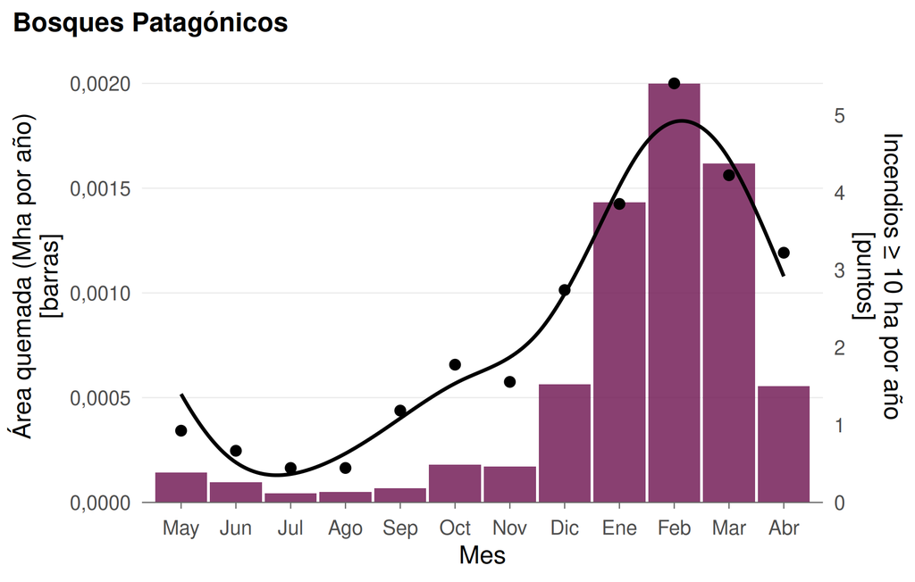

```r
for (r in REGIONES_PIRO) print(pirograma(r))
```

**Código**

```r
invisible(NULL)
```

Los cuatro pirogramas en números. `incendios_todos` está en los CSV pero **no se dibuja**: la línea es la de 10 hectáreas o más, que es la que no depende de dónde corta la resolución del mapeo.

**Código**

```r
pt <- rbindlist(lapply(PIROS, piro_tab))
tbl(dcast(pt, orden_mayo_abril + mes_nombre ~ region,
          value.var = "Mha_quemadas")[order(orden_mayo_abril)][
            , .(mes = mes_nombre, Argentina, `Delta e Islas del Paraná`, Chaco,
                `Bosques Patagónicos`)],
    align = "lrrrr")
```

| mes | Argentina | Delta e Islas del Paraná | Chaco | Bosques Patagónicos |
| --- | --- | --- | --- | --- |
| May | 0,03856 | 0,00236 | 0,01880 | 0,00014 |
| Jun | 0,06849 | 0,00464 | 0,03825 | 0,00010 |
| Jul | 0,17368 | 0,01503 | 0,10275 | 0,00004 |
| Ago | 0,41927 | 0,02865 | 0,25388 | 0,00005 |
| Sep | 0,37468 | 0,01667 | 0,24637 | 0,00007 |
| Oct | 0,20833 | 0,00687 | 0,12632 | 0,00018 |
| Nov | 0,13008 | 0,00288 | 0,05559 | 0,00017 |
| Dic | 0,24598 | 0,00317 | 0,02991 | 0,00056 |
| Ene | 0,35587 | 0,00734 | 0,05105 | 0,00143 |
| Feb | 0,19248 | 0,00591 | 0,04917 | 0,00200 |
| Mar | 0,09085 | 0,00249 | 0,02925 | 0,00162 |
| Abr | 0,04375 | 0,00392 | 0,01656 | 0,00055 |

## El inventario de la carpeta, y la compuerta

El cuaderno se revisa a sí mismo antes de terminar. **Dos cosas se verifican acá** y una tercera está resuelta en otro lado:

1. **Que todo lo que el texto nombra exista.** Cada `figNN_...` escrito entre comillas simples en la prosa se busca en lo que realmente se escribió. Prometer un archivo que no está es el error más caro, porque el diseñador lo descubre recién cuando abre la carpeta.
2. **Que no sobre nada.** Un archivo de una corrida vieja, con un nombre que ya no se usa, se entrega igual y nadie se entera. Los nombres cambiaron varias veces en este cuaderno.

Lo tercero, **que toda figura escrita se vea también en este HTML**, no se comprueba con una lista sino que está resuelto por construcción: `save2()` devuelve el plot de forma **visible**, así que cualquier chunk que termine en `save2(...)` la dibuja. Los dos chunks que sólo escriben en un bucle terminan en `invisible(NULL)` para no duplicar lo que se muestra más abajo. Fue un error real: la torta de dos anillos estuvo una corrida entera en la carpeta y ausente del HTML, porque `save2()` devolvía `invisible()` y nadie lo notaba desde adentro.

```
⚠️ EN LA CARPETA Y NO GENERADAS POR ESTA CORRIDA (borrar):
  - fig01_mapa_anios_quemados_presentation
 - fig02_torta_dos_anillos_presentation
 - fig03_05_mapa_ultimo_fuego_monte_presentation
 - fig03_06_mapa_ultimo_fuego_espinal_presentation
 - fig03_07_mapa_ultimo_fuego_delta_e_islas_del_parana_presentation
 - fig03_08_mapa_ultimo_fuego_bosques_patagonicos_presentation
 - fig03_mapa_ultimo_fuego_presentation
 - fig04_serie_argentina_bars_cobertura_pct
 - fig04_serie_argentina_bars_trend_cobertura
 - fig04_serie_argentina_bars_trend
 - fig04_serie_argentina_bars
 - fig04_serie_argentina_presentation
 - fig05_serie_monte_bars_tendencia
 - fig05_serie_monte_bars_trend
 - fig05_serie_monte_bars
 - fig05_serie_monte_presentation
 - fig06_serie_espinal_bars_tendencia
 - fig06_serie_espinal_bars_trend
 - fig06_serie_espinal_bars
 - fig06_serie_espinal_presentation
 - fig07_serie_delta_e_islas_del_parana_bars_tendencia
 - fig07_serie_delta_e_islas_del_parana_bars_trend
 - fig07_serie_delta_e_islas_del_parana_bars
 - fig07_serie_delta_e_islas_del_parana_presentation
 - fig08_serie_bosques_patagonicos_bars_tendencia
 - fig08_serie_bosques_patagonicos_bars_trend
 - fig08_serie_bosques_patagonicos_bars
 - fig08_serie_bosques_patagonicos_presentation
 - fig09_pirograma_argentina_presentation
 - fig10-11-12_pirogramas_regiones_presentation

75 archivos en collection-01/data/statistics/factsheet_sep2026_figures_and_tables

 - factsheet_sep2026.html
 - fig01_mapa_anios_quemados_presentation.png
 - fig01_mapa_anios_quemados.pdf
 - fig01_mapa_anios_quemados.png
 - fig02_barras_cobertura.pdf
 - fig02_barras_cobertura.png
```

[output cut: 54 more lines]

```
 - fig09_pirograma_argentina_presentation.png
 - fig09_pirograma_argentina.pdf
 - fig09_pirograma_argentina.png
 - fig10_datos.csv
 - fig10_pirograma_delta_e_islas_del_parana.pdf
 - fig10_pirograma_delta_e_islas_del_parana.png
 - fig10-11-12_pirogramas_regiones_presentation.png
 - fig10-11-12_pirogramas_regiones.pdf
 - fig10-11-12_pirogramas_regiones.png
 - fig11_datos.csv
 - fig11_pirograma_chaco.pdf
 - fig11_pirograma_chaco.png
 - fig12_datos.csv
 - fig12_pirograma_bosques_patagonicos.pdf
 - fig12_pirograma_bosques_patagonicos.png
```

Para regenerar todo:

```bash
quarto render collection-01/notebooks/factsheet_sep2026.qmd
```